# Assignment 4: Cluster Analysis of Pharmaceutical Companies

Nusrat Nasir Nimnee

2025-10-27

### **Purpose**

The purpose of this assignment is to use the k-Means clustering algorithm to explore and understand the structure of the pharmaceutical industry by analyzing financial data from 21 firms.

### **1. Data Loading and Preparation**

First, we will load the necessary libraries and import the data from the `Pharmaceuticals.csv` file.

```r
# Load necessary libraries
library(tidyverse)    # For data manipulation and visualization
library(cluster)      # For clustering algorithms
library(factoextra)   # For visualizing clustering results

# Load the dataset
pharma_data <- read.csv("Pharmaceuticals.csv")
```

### **a) Cluster Analysis and Justification of Choices**

In this step, we will conduct the cluster analysis using only the numerical variables (1 to 9) and justify the choices made.

#### **Data Pre-processing: Variable Selection and Scaling**

As per the assignment directions, we will use the first nine numerical financial variables: `Market_Cap`, `Beta`, `PE_Ratio`, `ROE`, `ROA`, `Asset_Turnover`, `Leverage`, `Rev_Growth`, and `Net_Profit_Margin`.

**Justification for Scaling:** The k-Means algorithm is based on Euclidean distance, which is sensitive to the scale of variables. For instance, `Market_Cap` (in billions) has a much larger scale than `Beta`. If we do not scale the data, variables with larger scales will disproportionately influence the clustering result. Therefore, we will **standardize** the data (to have a mean of 0 and a standard deviation of 1) to ensure all variables contribute equally to the analysis.

```r
# Select only the numerical variables for clustering (columns 3 to 11)
pharma_numeric <- pharma_data[, 3:11]

# Set company names as row names for easier identification
rownames(pharma_numeric) <- pharma_data$Name

# Scale (standardize) the data
pharma_scaled <- scale(pharma_numeric)

# View the first few rows of the scaled data
head(pharma_scaled)
```

```
##                     Market_Cap        Beta    PE_Ratio         ROE        ROA
## Abbott Laboratories  0.1840960 -0.80125356 -0.04671323  0.04009035  0.2416121
## Allergan, Inc.      -0.8544181 -0.45070513  3.49706911 -0.85483986 -0.9422871
## Amersham plc        -0.8762600 -0.25595600 -0.29195768 -0.72225761 -0.5100700
## AstraZeneca PLC      0.1702742 -0.02225704 -0.24290879  0.10638147  0.9181259
## Aventis             -0.1790256 -0.80125356 -0.32874435 -0.26484883 -0.5664461
## Bayer AG            -0.6953818  2.27578267  0.14948233 -1.45146000 -1.7127612
##                     Asset_Turnover   Leverage Rev_Growth Net_Profit_Margin
## Abbott Laboratories      0.0000000 -0.2120979 -0.5277675        0.06168225
## Allergan, Inc.           0.9225312  0.0182843 -0.3811391       -1.55366706
## Amersham plc             0.9225312 -0.4040831 -0.5721181       -0.68503583
## AstraZeneca PLC          0.9225312 -0.7496565  0.1474473        0.35122600
## Aventis                 -0.4612656 -0.3144900  1.2163867       -0.42597037
## Bayer AG                -0.4612656 -0.7496565 -1.4971443       -1.99560225
```

#### **Determining the Optimal Number of Clusters (k)**

To choose an appropriate number of clusters, `k`, we will use two data-driven methods: the **Elbow Method** and the **Average Silhouette Method**.

**Justification for Choice of k:** These methods provide a systematic way to determine the optimal `k` by evaluating the quality of the clustering for different values of `k`. This avoids arbitrary selection and leads to more meaningful clusters.

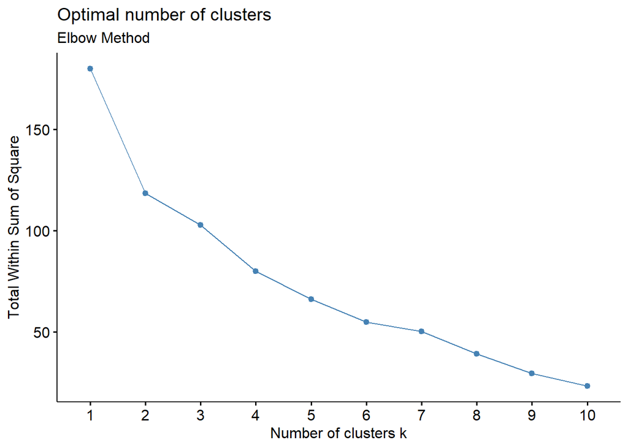

```r
# Determine optimal k using the Elbow Method
fviz_nbclust(pharma_scaled, kmeans, method = "wss") +
  labs(subtitle = "Elbow Method")
```

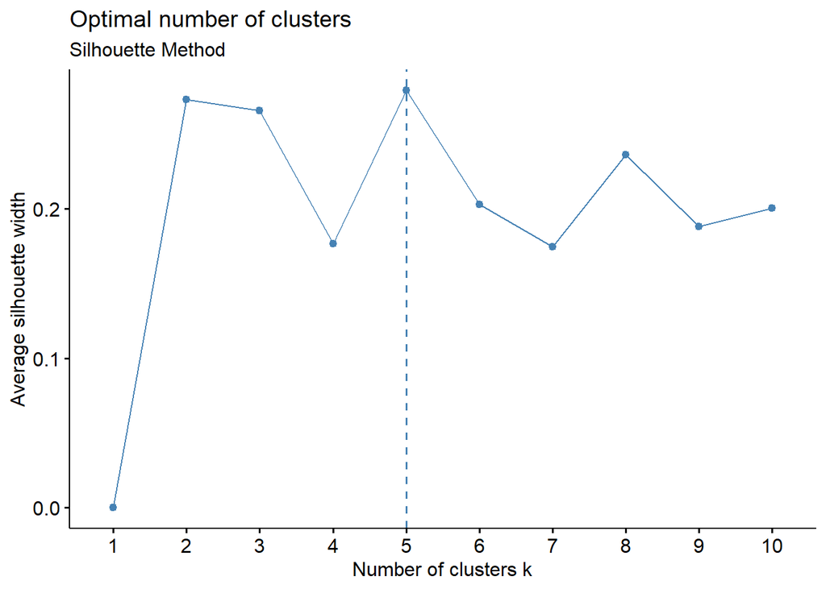

```r
# Determine optimal k using the Silhouette Method
fviz_nbclust(pharma_scaled, kmeans, method = "silhouette") +
  labs(subtitle = "Silhouette Method")
```

#### **Performing k-Means Clustering**

```r
# Set a seed for reproducibility
set.seed(123)

# Perform k-Means clustering with k=3
final_clusters <- kmeans(pharma_scaled, centers = 3, nstart = 25)

# Print the clustering results
print(final_clusters)
```

```
## K-means clustering with 3 clusters of sizes 4, 11, 6
##
## Cluster means:
##   Market_Cap       Beta   PE_Ratio        ROE        ROA Asset_Turnover
## 1 -0.6125361  0.2698666  1.3143935 -0.9609057 -1.0174553      0.2306328
## 2  0.6733825 -0.3586419 -0.2763512  0.6565978  0.8344159      0.4612656
## 3 -0.8261772  0.4775991 -0.3696184 -0.5631589 -0.8514589     -0.9994088
##     Leverage Rev_Growth Net_Profit_Margin
## 1 -0.3592866 -0.5757385        -1.3784169
## 2 -0.3331068 -0.2902163         0.6823310
## 3  0.8502201  0.9158889        -0.3319956
##
## Clustering vector:
##                Abbott Laboratories                     Allergan, Inc.
##                                  2                                  1
##                       Amersham plc                    AstraZeneca PLC
##                                  1                                  2
##                            Aventis                           Bayer AG
##                                  3                                  1
##       Bristol-Myers Squibb Company                       Chattem, Inc
##                                  2                                  3
##              Elan Corporation, plc              Eli Lilly and Company
##                                  3                                  2
##                GlaxoSmithKline plc                   IVAX Corporation
##                                  2                                  3
##                  Johnson & Johnson Medicis Pharmaceutical Corporation
##                                  2                                  3
##                  Merck & Co., Inc.                        Novartis AG
##                                  2                                  2
##                         Pfizer Inc              Pharmacia Corporation
##                                  2                                  1
##        Schering-Plough Corporation       Watson Pharmaceuticals, Inc.
##                                  2                                  3
##                              Wyeth
##                                  2
##
## Within cluster sum of squares by cluster:
## [1] 20.54199 43.30886 32.14336
##  (between_SS / total_SS =  46.7 %)
##
## Available components:
##
## [1] "cluster"      "centers"      "totss"        "withinss"     "tot.withinss"
## [6] "betweenss"    "size"         "iter"         "ifault"
```

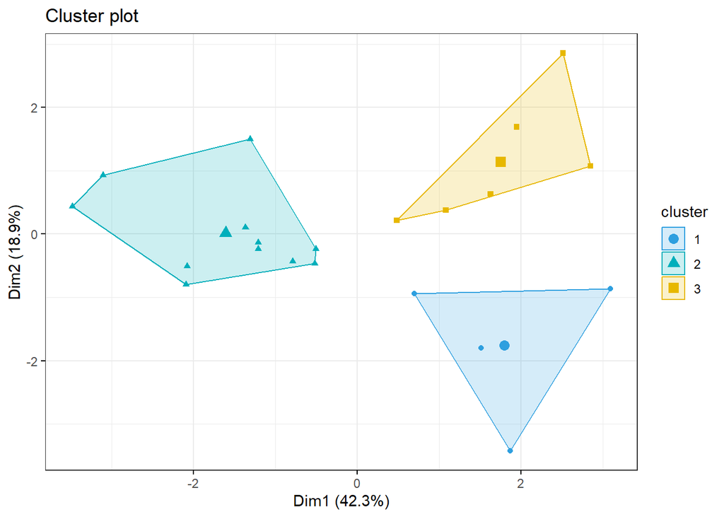

```r
# Visualize the clusters
fviz_cluster(final_clusters, data = pharma_scaled,
             palette = c("#2E9FDF", "#00AFBB", "#E7B800"),
             geom = "point",
             ellipse.type = "convex",
             ggtheme = theme_bw()
)
```

### **b) Interpretation of the Clusters**

To interpret the clusters, we will analyze the mean values of the original (unscaled) numerical variables for each cluster. This allows us to understand the real-world characteristics of each group.

```r
# Add the cluster assignment to the original numeric data
pharma_numeric_clustered <- pharma_numeric %>%
  mutate(Cluster = final_clusters$cluster)

# Calculate the mean of each variable for each cluster
cluster_summary <- pharma_numeric_clustered %>%
  group_by(Cluster) %>%
  summarise_all(mean)

# Print the summary table
print.data.frame(cluster_summary)
```

```
##   Cluster Market_Cap      Beta PE_Ratio  ROE       ROA Asset_Turnover  Leverage
## 1       1   21.75500 0.5950000 46.90000 11.3  5.100000      0.7500000 0.3050000
## 2       2   97.11364 0.4336364 20.95455 35.7 14.954545      0.8000000 0.3254545
## 3       3    9.23500 0.6483333 19.43333 17.3  5.983333      0.4833333 1.2500000
##   Rev_Growth Net_Profit_Margin
## 1    7.01000           6.65000
## 2   10.16455          20.17273
## 3   23.49000          13.51667
```

**Cluster Interpretations (Corrected):**

Based on the summary table above, we can interpret the clusters as follows:

- **Cluster 1: Stable, Highly-Valued Competitors.** These firms exhibit moderate `Market_Cap` ($21.8B) and `ROE` (11.3). Their most defining feature is the **highest average PE_Ratio (46.9)**, indicating strong investor confidence in their future, despite having the lowest revenue growth and net profit margin in this dataset.
- **Cluster 2: Large, Profitable Blue-Chip Firms.** This group represents the industry giants, with the **highest average Market_Cap ($97.1B)**, the **highest ROE (35.7)**, and the **highest Net_Profit_Margin (20.2%)**. Their financial performance is exceptionally strong and stable.
- **Cluster 3: High-Growth, High-Risk Emerging Firms.** This cluster contains the smallest firms, with the **lowest average Market_Cap ($9.2B)**. However, they compensate with the **highest Revenue Growth (23.5%)**. Their high-risk nature is evident from the **highest average Leverage (1.25)**.

### **c) Pattern with Respect to Non-clustering Variables**

Now, we examine if there is a pattern in the clusters with respect to the categorical variables (10-12) that were not used in forming the clusters.

```r
# Add cluster assignments to the categorical variables
pharma_full_clustered <- pharma_data %>%
  select(Name, Median_Recommendation, Location, Exchange) %>%
  mutate(Cluster = final_clusters$cluster)

# Pattern by Median Recommendation
cat("Cluster distribution by Median Recommendation:\n")
```

```
## Cluster distribution by Median Recommendation:
```

```r
table(pharma_full_clustered$Cluster, pharma_full_clustered$Median_Recommendation)
```

```
##
##     Hold Moderate Buy Moderate Sell Strong Buy
##   1    2            1             0          1
##   2    6            3             2          0
##   3    1            3             2          0
```

```r
# Pattern by Location
cat("\nCluster distribution by Location:\n")
```

```
##
## Cluster distribution by Location:
```

```r
table(pharma_full_clustered$Cluster, pharma_full_clustered$Location)
```

```
##
##     CANADA FRANCE GERMANY IRELAND SWITZERLAND UK US
##   1      1      0       1       0           0  1  1
##   2      0      0       0       0           1  2  8
##   3      0      1       0       1           0  0  4
```

```r
# Pattern by Stock Exchange
cat("\nCluster distribution by Stock Exchange:\n")
```

```
##
## Cluster distribution by Stock Exchange:
```

```r
table(pharma_full_clustered$Cluster, pharma_full_clustered$Exchange)
```

```
##
##     AMEX NASDAQ NYSE
##   1    0      0    4
##   2    0      0   11
##   3    1      1    4
```

**Observations:**

- **Median Recommendation:** Cluster 2 (Large Blue-Chips) firms are mostly rated as `Hold` or `Moderate Buy`. The other two clusters have more mixed recommendations.
- **Location:** Cluster 2 is dominated by firms headquartered in the **US** and **UK**. Most firms in Cluster 3 (High-Growth) are based in the **US**. Cluster 1 (Stable Competitors) is more geographically diverse.
- **Exchange:** Almost all firms in Cluster 1 and 2 are listed on the **NYSE**. The firms in Cluster 3 are listed on various exchanges, which is consistent with smaller, emerging companies.

### **d) Provide an Appropriate Name for Each Cluster**

Based on the combined financial and categorical analysis, we can provide the following descriptive names for each cluster:

- **Cluster 1: Stable International Competitors**
  - **Reason:** This group consists of well-established, geographically diverse firms with stable performance. Their high PE ratios indicate strong investor confidence in their long-term value, even with lower current profitability.
- **Cluster 2: Global Pharma Giants**
  - **Reason:** This group includes companies with massive market caps, superior profitability, and a dominant presence in major markets (US/UK) and on the premier stock exchange (NYSE).
- **Cluster 3: Dynamic Growth Seekers**
  - **Reason:** These are smaller, riskier firms characterized by their aggressive revenue growth. They are dynamic and likely focused on innovation or niche markets to challenge the established giants. ```